# Computing with Sequences and Ranges

Martin Morgan

Tuesday July 12

# 1 Sequences

```r
dna0 <- c("AACAT", "CCCACT")
```

- Could represent as simple character vector, but…
- Not all character vectors are DNA sequences
- Specialized methods are appropriate to DNA sequences, e.g., reverse complement

```r
dna <- DNAStringSet(dna0)
methods(class=class(dna))
```

```
##   [1] !                               !=
##   [3] [                               [[
##   [5] [[<-                            [<-
##   [7] %in%                            <
##   [9] <=                              ==
##  [11] >                               >=
##  [13] $                               $<-
##  [15] aggregate                       alphabetFrequency
##  [17] anyNA                           append
##  [19] as.character                    as.complex
##  [21] as.data.frame                   as.env
##  [23] as.integer                      as.list
##  [25] as.logical                      as.matrix
##  [27] as.numeric                      as.raw
##  [29] as.vector                       by
```

[output cut: 71 more lines]

```r
reverseComplement(dna)
```

```
##   A DNAStringSet instance of length 2
##     width seq
## [1]     5 ATGTT
## [2]     6 AGTGGG
```

A more extensive example

```r
seq
```

```
##   A DNAStringSet instance of length 277773
##           width seq
##      [1]    354 CTTGCCGTCAGCCTTTTCTTTGACCTCTTCTTTCTGTTCAT...AGATGAGTGAGAGCATCAACTTCTCTCACAACCTAGGCCA
##      [2]    127 GCTCCTGTCTCCCCCCAGGTGTGTGGTGATGCCAGGCATGC...CTTGGATCACACTCTTGTGAGTGTCCCCAGTGTTGCAGAG
##      [3]    109 GTGTGTGGTGATGCCAGGCATGCCCTTCCCCAGCATCAGGT...CTTGGATCACACTCTTGTGAGTGTCCCCAGTGTTGCAGAG
##      [4]     52 CATCAGGTCTCCAGAGCTGCAGAAGACGACGGCCGACTTGGATCACACTCTT
##      [5]   1189 GCAGGGCCATCAGGCACCAAAGGGATTCTGCCAGCATAGTG...AGCTAGAGATCCTTTATTAAAAGCACACTGTTGGTTTCTG
##      ...    ... ...
## [277769]    700 TTATGTGATTAGGAGTAGGGTTAGGATGAGTGGGAAGAAGA...AGGTATTCCTGCTAATGCTAGGCTGCCAATGGTGAGGGAG
## [277770]    171 TTATGTGATTAGGAGTAGGGTTAGGATGAGTGGGAAGAAGA...GCTTTTCTAGTCAGGTTAGGTCTAGGAGGAGTAGGGGCAG
## [277771]     24 GTGGTTGTAGTCCGTGCGAGAATA
## [277772]    385 AGGCCCATTTGAGTATTTTGTTTTCAATTAGGGAGATAGTT...GAGGGGTGTTTAAGGGGTTGGCTAGGGTATAATTGTCTGG
## [277773]     65 CAGAGAATAGTTTAAATTAGAATCTTAGCTTTGGGTGCTAATGGTGGAGTTAAAGACTTTTTCTC
```

```r
head(width(seq))
```

```
## [1]  354  127  109   52 1189 1007
```

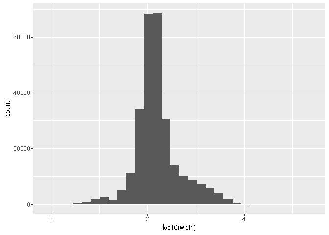

```r
df <- data.frame(
    width=width(seq),
    GC=letterFrequency(seq, "GC", as.prob=TRUE)[, "G|C"])
ggplot(df, aes(x=log10(width))) + geom_histogram()
```

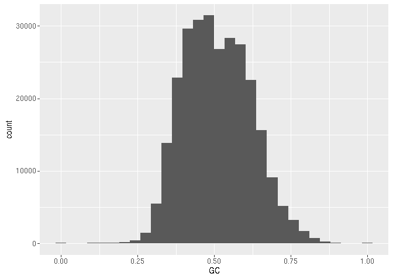

```r
ggplot(df, aes(x=GC)) + geom_histogram()
```

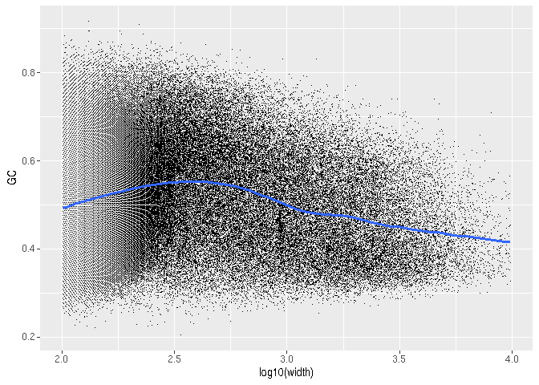

```r
ggplot(subset(df, width > 100 & width < 10000), aes(x=log10(width), y=GC)) +
    geom_point(pch=".") + geom_smooth()
```

Advanced concept:

- ‘Vector’-like – `length()`, `[`, `[[`

# 2 Ranges

```r
q <- GRanges("chr1", IRanges(10, 20))
s <- GRanges("chr1", IRanges(5, width=c(3, 6, 9)))
findOverlaps(q, s)
```

```
## Hits object with 2 hits and 0 metadata columns:
##       queryHits subjectHits
##       <integer>   <integer>
##   [1]         1           2
##   [2]         1           3
##   -------
##   queryLength: 1 / subjectLength: 3
```

A more extensive example

```r
ex
```

```
## GRanges object with 277773 ranges and 0 metadata columns:
##            seqnames         ranges strand
##               <Rle>      <IRanges>  <Rle>
##        [1]     chr1 [11874, 12227]      +
##        [2]     chr1 [12595, 12721]      +
##        [3]     chr1 [12613, 12721]      +
##        [4]     chr1 [12646, 12697]      +
##        [5]     chr1 [13221, 14409]      +
##        ...      ...            ...    ...
##   [277769]     chrM [13450, 14149]      -
##   [277770]     chrM [13979, 14149]      -
##   [277771]     chrM [14675, 14698]      -
##   [277772]     chrM [15504, 15888]      -
##   [277773]     chrM [15960, 16024]      -
##   -------
##   seqinfo: 25 sequences (1 circular) from hg19 genome
```

```r
table(strand(ex))
```

```
##
##      +      -      *
## 137629 140144      0
```

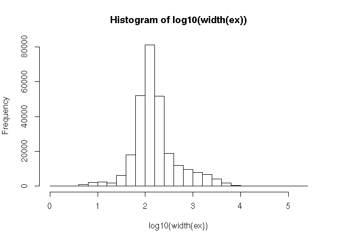

```r
hist(log10(width(ex)))
```

```r
flank(ex, 1000)
```

```
## GRanges object with 277773 ranges and 0 metadata columns:
##            seqnames         ranges strand
##               <Rle>      <IRanges>  <Rle>
##        [1]     chr1 [10874, 11873]      +
##        [2]     chr1 [11595, 12594]      +
##        [3]     chr1 [11613, 12612]      +
##        [4]     chr1 [11646, 12645]      +
##        [5]     chr1 [12221, 13220]      +
##        ...      ...            ...    ...
##   [277769]     chrM [14150, 15149]      -
##   [277770]     chrM [14150, 15149]      -
##   [277771]     chrM [14699, 15698]      -
##   [277772]     chrM [15889, 16888]      -
##   [277773]     chrM [16025, 17024]      -
##   -------
##   seqinfo: 25 sequences (1 circular) from hg19 genome
```

Arbitrary additional columns

```r
ex$seq <- seq
ex$GC <- letterFrequency(seq, "GC", as.prob=TRUE)[, "G|C"]
ex
```

```
## GRanges object with 277773 ranges and 2 metadata columns:
##            seqnames         ranges strand |                     seq        GC
##               <Rle>      <IRanges>  <Rle> |          <DNAStringSet> <numeric>
##        [1]     chr1 [11874, 12227]      + | CTTGCCGTCA...ACCTAGGCCA 0.5169492
##        [2]     chr1 [12595, 12721]      + | GCTCCTGTCT...TGTTGCAGAG 0.6062992
##        [3]     chr1 [12613, 12721]      + | GTGTGTGGTG...TGTTGCAGAG 0.5871560
##        [4]     chr1 [12646, 12697]      + | CATCAGGTCT...TCACACTCTT 0.5576923
##        [5]     chr1 [13221, 14409]      + | GCAGGGCCAT...TTGGTTTCTG 0.5626577
##        ...      ...            ...    ... .                     ...       ...
##   [277769]     chrM [13450, 14149]      - | TTATGTGATT...GGTGAGGGAG 0.4542857
##   [277770]     chrM [13979, 14149]      - | TTATGTGATT...GTAGGGGCAG 0.4152047
##   [277771]     chrM [14675, 14698]      - | GTGGTTGTAG...TGCGAGAATA 0.5000000
##   [277772]     chrM [15504, 15888]      - | AGGCCCATTT...AATTGTCTGG 0.4363636
##   [277773]     chrM [15960, 16024]      - | CAGAGAATAG...ACTTTTTCTC 0.3384615
##   -------
##   seqinfo: 25 sequences (1 circular) from hg19 genome
```

Information about ranges

```r
seqinfo(ex)
```

```
## Seqinfo object with 25 sequences (1 circular) from hg19 genome:
##   seqnames seqlengths isCircular genome
##   chr1      249250621       <NA>   hg19
##   chr2      243199373       <NA>   hg19
##   chr3      198022430       <NA>   hg19
##   chr4      191154276       <NA>   hg19
##   chr5      180915260       <NA>   hg19
##   ...             ...        ...    ...
##   chr21      48129895       <NA>   hg19
##   chr22      51304566       <NA>   hg19
##   chrX      155270560       <NA>   hg19
##   chrY       59373566       <NA>   hg19
##   chrM          16571       TRUE   hg19
```

# 3 What’s to love about a data.frame?

- Coordination
- Familiarity
- Interoperability

And yet…

- How are two data.frame’s related to one another?
- Meaning *of* columns in a data.frame?
- All columns are not equal
- Not every column is a base R vector

Loving, leaving, and coming back

```r
library(tibble)
ex
```

```
## GRanges object with 277773 ranges and 2 metadata columns:
##            seqnames         ranges strand |                     seq        GC
##               <Rle>      <IRanges>  <Rle> |          <DNAStringSet> <numeric>
##        [1]     chr1 [11874, 12227]      + | CTTGCCGTCA...ACCTAGGCCA 0.5169492
##        [2]     chr1 [12595, 12721]      + | GCTCCTGTCT...TGTTGCAGAG 0.6062992
##        [3]     chr1 [12613, 12721]      + | GTGTGTGGTG...TGTTGCAGAG 0.5871560
##        [4]     chr1 [12646, 12697]      + | CATCAGGTCT...TCACACTCTT 0.5576923
##        [5]     chr1 [13221, 14409]      + | GCAGGGCCAT...TTGGTTTCTG 0.5626577
##        ...      ...            ...    ... .                     ...       ...
##   [277769]     chrM [13450, 14149]      - | TTATGTGATT...GGTGAGGGAG 0.4542857
##   [277770]     chrM [13979, 14149]      - | TTATGTGATT...GTAGGGGCAG 0.4152047
##   [277771]     chrM [14675, 14698]      - | GTGGTTGTAG...TGCGAGAATA 0.5000000
##   [277772]     chrM [15504, 15888]      - | AGGCCCATTT...AATTGTCTGG 0.4363636
##   [277773]     chrM [15960, 16024]      - | CAGAGAATAG...ACTTTTTCTC 0.3384615
##   -------
##   seqinfo: 25 sequences (1 circular) from hg19 genome
```

```r
as_tibble(ex)
```

```
## # A tibble: 277,773 x 7
##    seqnames  start    end width strand
##      <fctr>  <int>  <int> <int> <fctr>
## 1      chr1  11874  12227   354      +
## 2      chr1  12595  12721   127      +
## 3      chr1  12613  12721   109      +
## 4      chr1  12646  12697    52      +
## 5      chr1  13221  14409  1189      +
## 6      chr1  13403  14409  1007      +
## 7      chr1  69091  70008   918      +
## 8      chr1 321084 321115    32      +
## 9      chr1 321146 321207    62      +
## 10     chr1 322037 322228   192      +
## # ... with 277,763 more rows, and 2 more variables: seq <chr>, GC <dbl>
```

What have I lost?

- ‘Required’ columns
- Constraints on columns – width == end - start + 1; >= 0
- Semantic meaning – strand
- Properties of DNAStringSet
- Metadata

Coming back

```r
as_tibble(ex) %>% makeGRangesFromDataFrame
```

```
## GRanges object with 277773 ranges and 0 metadata columns:
##            seqnames         ranges strand
##               <Rle>      <IRanges>  <Rle>
##        [1]     chr1 [11874, 12227]      +
##        [2]     chr1 [12595, 12721]      +
##        [3]     chr1 [12613, 12721]      +
##        [4]     chr1 [12646, 12697]      +
##        [5]     chr1 [13221, 14409]      +
##        ...      ...            ...    ...
##   [277769]     chrM [13450, 14149]      -
##   [277770]     chrM [13979, 14149]      -
##   [277771]     chrM [14675, 14698]      -
##   [277772]     chrM [15504, 15888]      -
##   [277773]     chrM [15960, 16024]      -
##   -------
##   seqinfo: 25 sequences from an unspecified genome; no seqlengths
```

Principled versus precocious?

- The tidyverse as principled – a few well-designed orthogonal functions operating exclusively (?) on data.frame derivatives
- *R* and *Bioconductor* as precocious – a large number of classes and specialized functions
- Some of preciousness is lack of principle, but some reflects high-level summary of complex work flows